# *Blog: Feminism Through Philosophy*

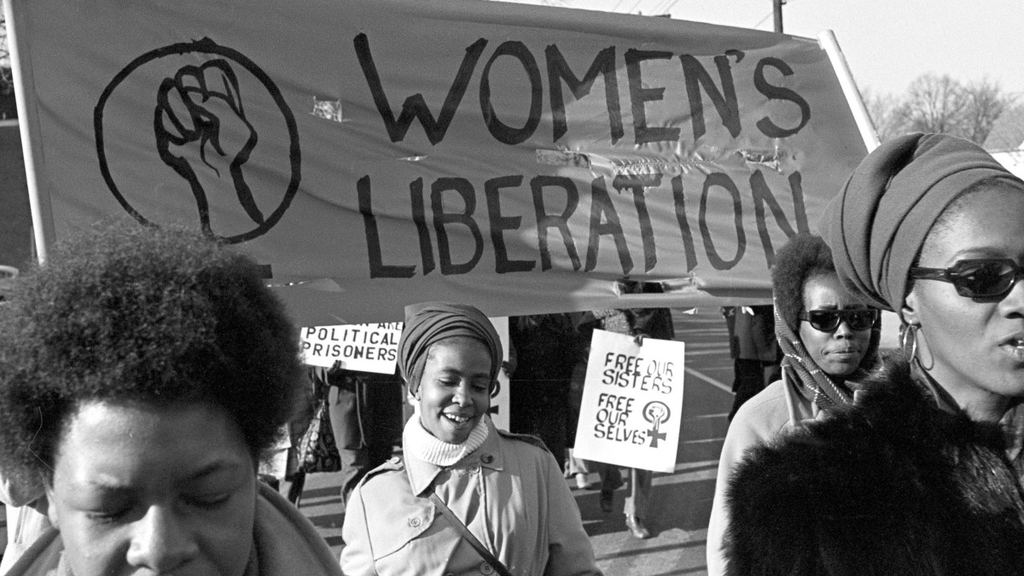

Currently, politically, economically, and systematically, women are disadvanted. Because a lot of philosophical writings have shaped the fundamentals of our current economical and political systems, NLP approach to philosopical data will certainly help us understand what issues had been addressed by phisophers and what values were missing. Mostly we will focus on only feminism school here. Are the struggles and claims of women similar or diverse among the feminism philosophers? This is my question to be answered. The feminism school philosophers are as follows:

[output not shown]

After my analysis among the feminism shcool, we will move on to comparing other schools. Later in this blog, you will see several philosophers mentioned **"man"** (and associated words) more frequently than **"woman"** (and associated words) despite gender being irrelevant to the topics of thier focus. This will reveal which topics/values women are marginalized from.

As a whole, I will be disuccing below:

## *■ Agenda ■*

### 1.Data Processing

> - Sentiement/Emotion Score
> - Gender Mntioend Score

### 2.Analysis in Feminism School

> - Complexity of Words
> - Sentiment Analysis
> - Most Frequently Used Words
> - Dynamics of Relationship
> - Article Summarization
> - Topic Modeling

### 3.Comparison with Other School Philosophers

> - Why Do We Need to Look at Other School Philosophers?
> - Most Frequently Used Words

### 4.Summary

# *1. Data Processing*

This is our data on western philosophy from Kaggle.  
The data contains 13 schools, 36 philosophers, and 59 publications.  
Original publication dates range from BC.350 to AD.1985. Of course, the dataset contains text data from thier articles.

|  | title | author | school | sentence_spacy | sentence_str | original_publication_date | corpus_edition_date | sentence_length | sentence_lowered | tokenized_txt | lemmatized_str |
| --- | --- | --- | --- | --- | --- | --- | --- | --- | --- | --- | --- |
| 0 | Plato - Complete Works | Plato | plato | What's new, Socrates, to make you leave your ... | What's new, Socrates, to make you leave your ... | -350 | 1997 | 125 | what's new, socrates, to make you leave your ... | ['what', 'new', 'socrates', 'to', 'make', 'you... | what be new , Socrates , to make -PRON- lea... |
| 1 | Plato - Complete Works | Plato | plato | Surely you are not prosecuting anyone before t... | Surely you are not prosecuting anyone before t... | -350 | 1997 | 69 | surely you are not prosecuting anyone before t... | ['surely', 'you', 'are', 'not', 'prosecuting',... | surely -PRON- be not prosecute anyone before ... |
| 2 | Plato - Complete Works | Plato | plato | The Athenians do not call this a prosecution b... | The Athenians do not call this a prosecution b... | -350 | 1997 | 74 | the athenians do not call this a prosecution b... | ['the', 'athenians', 'do', 'not', 'call', 'thi... | the Athenians do not call this a prosecution ... |
| 3 | Plato - Complete Works | Plato | plato | What is this you say? | What is this you say? | -350 | 1997 | 21 | what is this you say? | ['what', 'is', 'this', 'you', 'say'] | what be this -PRON- say ? |
| 4 | Plato - Complete Works | Plato | plato | Someone must have indicted you, for you are no... | Someone must have indicted you, for you are no... | -350 | 1997 | 101 | someone must have indicted you, for you are no... | ['someone', 'must', 'have', 'indicted', 'you',... | someone must have indict -PRON- , for -PRON- ... |

You can see the variety of schools and philosophers.

```
['plato' 'aristotle' 'empiricism' 'rationalism' 'analytic' 'continental'
 'phenomenology' 'german_idealism' 'communism' 'capitalism' 'stoicism'
 'nietzsche' 'feminism']
```

```
['Plato' 'Aristotle' 'Locke' 'Hume' 'Berkeley' 'Spinoza' 'Leibniz'
 'Descartes' 'Malebranche' 'Russell' 'Moore' 'Wittgenstein' 'Lewis'
 'Quine' 'Popper' 'Kripke' 'Foucault' 'Derrida' 'Deleuze' 'Merleau-Ponty'
 'Husserl' 'Heidegger' 'Kant' 'Fichte' 'Hegel' 'Marx' 'Lenin' 'Smith'
 'Ricardo' 'Keynes' 'Epictetus' 'Marcus Aurelius' 'Nietzsche'
 'Wollstonecraft' 'Beauvoir' 'Davis']
```

## Sentiments & Emotions Score

Using NRC data to evaluate the 7 emotions (fear, trust, joy, disgust, anticipation, sadness, surprise) and 2 sentiments (negative, positive), we can assign score index 1 to text whenever there are associated words in it.

For example, the following sentence contains some positive words and a few negative words.

> " what's new, socrates, to make you leave your usual haunts in the lyceum and spend your time here by the king archon's court?"

```
{'disgust': 0,
 'trust': 1,
 'negative': 1,
 'anger': 0,
 'joy': 0,
 'fear': 0,
 'surprise': 1,
 'positive': 2,
 'sadness': 1,
 'anticipation': 1}
```

You can see that the 2 sentiments and 7 emotions score were given across the data set.

|  | title | author | school | sentence_spacy | sentence_str | original_publication_date | corpus_edition_date | sentence_length | sentence_lowered | tokenized_txt | ... | negative | positive | joy | disgust | anticipation | sadness | surprise | all_pos | all_neg | overview_net |
| --- | --- | --- | --- | --- | --- | --- | --- | --- | --- | --- | --- | --- | --- | --- | --- | --- | --- | --- | --- | --- | --- |
| 0 | Plato - Complete Works | Plato | plato | What's new, Socrates, to make you leave your ... | What's new, Socrates, to make you leave your ... | -350 | 1997 | 125 | what's new, socrates, to make you leave your ... | ['what', 'new', 'socrates', 'to', 'make', 'you... | ... | 1 | 2 | 0 | 0 | 1 | 1 | 1 | 4 | 2 | 2 |
| 1 | Plato - Complete Works | Plato | plato | Surely you are not prosecuting anyone before t... | Surely you are not prosecuting anyone before t... | -350 | 1997 | 69 | surely you are not prosecuting anyone before t... | ['surely', 'you', 'are', 'not', 'prosecuting',... | ... | 0 | 1 | 0 | 0 | 0 | 0 | 0 | 1 | 0 | 1 |
| 2 | Plato - Complete Works | Plato | plato | The Athenians do not call this a prosecution b... | The Athenians do not call this a prosecution b... | -350 | 1997 | 74 | the athenians do not call this a prosecution b... | ['the', 'athenians', 'do', 'not', 'call', 'thi... | ... | 1 | 0 | 0 | 1 | 0 | 0 | 0 | 0 | 2 | -2 |
| 3 | Plato - Complete Works | Plato | plato | What is this you say? | What is this you say? | -350 | 1997 | 21 | what is this you say? | ['what', 'is', 'this', 'you', 'say'] | ... | 0 | 0 | 0 | 0 | 0 | 0 | 0 | 0 | 0 | 0 |
| 4 | Plato - Complete Works | Plato | plato | Someone must have indicted you, for you are no... | Someone must have indicted you, for you are no... | -350 | 1997 | 101 | someone must have indicted you, for you are no... | ['someone', 'must', 'have', 'indicted', 'you',... | ... | 0 | 0 | 0 | 0 | 0 | 0 | 0 | 0 | 0 | 0 |

5 rows × 24 columns

## Gender Mentioned Flag / Times

For futher analysis, the following indices will be computed. Both indices can quantify how many times both genders were mentioned in every text.

1. **Flag**: if gender associated words were mentioned in a sentence.
2. **Times**: count how many times gender associated words were mentioned in a sentence.

For **Flag and Times**, the following list will be used to catch and contribute to both indices. Most of the words of course include their plural terms.

```
fWordsList = ["lady", "ladies", "woman", "women", "female", "females", "grandmother", "grandmothers", "grandma", "grandmas", "mother", "mothers", "sister", "sisters", "mom", "girl", "girls", "wife", "wives", "housewife", "housewives", "madam", "madame", "daughter","daughters", "she", "her", "herself"]
mWordsList = ["man", "men", "gentleman", "gentlemen", "grandfather", "grandgathers", "grandpa", "grandpas", "father", "fathers", "brother", "brothers", "dad", "boy", "boys", "guy", "guys", "husband", "husbands", "son","sons", "he", "his", "him", "himself"]
```

After the process, you can see, for instance, one sentence had mentioned female associated words **20 times** whereas another sentence had mentioned male associated words **26 times**.

The following sentence mentions female 20 times...

|  | title | author | school | sentence_spacy | sentence_str | original_publication_date | corpus_edition_date | sentence_length | sentence_lowered | tokenized_txt | ... | anticipation | sadness | surprise | all_pos | all_neg | overview_net | female_mentioned | male_mentioned | female_mentioned_times | male_mentioned_times |
| --- | --- | --- | --- | --- | --- | --- | --- | --- | --- | --- | --- | --- | --- | --- | --- | --- | --- | --- | --- | --- | --- |
| 353940 | The Second Sex | Beauvoir | feminism | If she sincerely desires her pregnancy, it wil... | If she sincerely desires her pregnancy, it wil... | 1949 | 2009 | 838 | if she sincerely desires her pregnancy, it wil... | ['if', 'she', 'sincerely', 'desires', 'her', '... | ... | 7 | 4 | 3 | 22 | 11 | 11 | 1 | 1 | 20 | 2 |

1 rows × 28 columns

> If she sincerely desires her pregnancy, it will be of utmost importance for her to carry it out without assistance; stilldominated and consenting to it, she will put herself, on the contrary, in her mother's hands: the newborn will seem like a brother or sister to her rather than her own offspring; if at the same time she wants and does not dare to liberate herself, she fears that the child, instead of saving her, will make her fall back under the yoke: this anguish can cause miscarriages; Deutsch cites the case of a young woman who, having to accompany her husband on a trip and leaving the child with her mother, gave birth to a stillborn child; she wondered why she had not mourned it more because she had ardently desired it; but she would have hated giving it over to her mother, whowould havedominated her through this child.

The following sentence mentions male 26 times...

|  | title | author | school | sentence_spacy | sentence_str | original_publication_date | corpus_edition_date | sentence_length | sentence_lowered | tokenized_txt | ... | anticipation | sadness | surprise | all_pos | all_neg | overview_net | female_mentioned | male_mentioned | female_mentioned_times | male_mentioned_times |
| --- | --- | --- | --- | --- | --- | --- | --- | --- | --- | --- | --- | --- | --- | --- | --- | --- | --- | --- | --- | --- | --- |
| 345904 | The Second Sex | Beauvoir | feminism | On the contrary, the worker fashions a tool ac... | On the contrary, the worker fashions a tool ac... | 1949 | 2009 | 1118 | on the contrary, the worker fashions a tool ac... | ['on', 'the', 'contrary', 'the', 'worker', 'fa... | ... | 4 | 0 | 1 | 21 | 3 | 18 | 0 | 1 | 0 | 26 |

1 rows × 28 columns

> On the contrary, the worker fashions a tool according to his own design; he imposes on it the form that fits his project; facing an inert nature that defies him but that he overcomes, he asserts himself as sovereign will; if he quickens his strokes on the anvil, he quickens the completion of the tool, whereas nothing can hasten the ripening of grain; his responsibility develops with what he makes: his movement, adroit or maladroit, makes it or breaks it; careful, skillful, he brings it to a point of perfection he can be proud of: his success depends not on the favor of the gods but on himself; he challenges his fellow workers, he takes pride in his success; and while he still leaves some place for rituals, applied techniques seem far more important to him; mystical values become secondary, and practical interests take precedence; he is not entirely liberated from the gods, but he distances himself by distancing them from himself; he relegates them to their Olympian heaven and keeps the terrestrialdomain for himself; the great Pan begins to fade at the first sound of his hammer, and man's reign begins.

Both sentences were unsurprisingly from a text of the feminism school.

### Before moving on to the next section, let's look at an interesting findings based on the computed result at this moment.

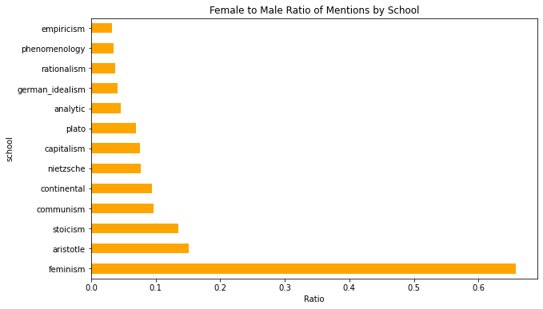

What about the breakdown by **philosophers**?  
Similar to the previous graph, the graph below shows significant disparity in ratio between feminism philosophers and the other authors.  
(This graph only shows the top 20 out of 36 authors.)

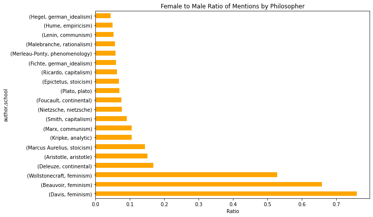

# *2. Analysis in Feminism School*

If you might recall, feminism school/authors have mentioned female associated words in their articles. We would like to dig deeper about their values and claims. Of course, NLP methods will be applied instead of reading the literature reviews. Therefore, the analysis output could be different from what it is in reality. In order to be as insightful as possible, several methodologies will be conducted.

- **Text Complexity**  
  Despite being from the same school, each author should have their own writing style. We will look at how thier writing styles will vary.
- **Sentiment Analysis**  
  Using the sentiment and emotion score created earlier, we are going to get the sense of the philosophers' emotions and sentiments through their articles.
- **Most Frequenty Used Words**  
  Excluding the stopping word("a”, “the”, “is”, “are” and etc), knowing the most frequently used words will be useful information to get to know the topic.
- **Relationship Dynamics**  
  Based on the result from 3, dispersion plots will give more insight into the relationship between the frequently used words.
- **Article Summarization**  
  Finally, we will summarize each article by picking up 3 most relevant sentences. The method will be detailed later in the section.
- **Topic Modeling**  
  In spite of the differnt titles, they should have something in common. Topic modeling can reveal more topics than what we assume from the titles.

## Text Complexity

Here are three indices for text complexity

1. Word Size
2. Sentence Size
3. Vocabulary to Text

| author | title | original_publication_date | corpus_edition_date | sentence_length | count | fear | trust | negative | positive | joy | disgust | ... | male_mentioned | female_mentioned_times | male_mentioned_times | num_vocab | num_chars | num_words | num_sentences | word_size | sent_size | vocab_to_text |
| --- | --- | --- | --- | --- | --- | --- | --- | --- | --- | --- | --- | --- | --- | --- | --- | --- | --- | --- | --- | --- | --- | --- |
| Wollstonecraft | Vindication Of The Rights Of Woman | 4585728 | 5120559 | 488661 | 2559 | 1174 | 2936 | 2536 | 5372 | 1949 | 803 | ... | 683 | 1324 | 1187 | 77228 | 488661 | 96398 | 2568 | 5.069203 | 37.538162 | 0.801137 |
| Beauvoir | The Second Sex | 25370133 | 26151153 | 1936804 | 13017 | 5439 | 9053 | 10663 | 15789 | 7590 | 3503 | ... | 3560 | 17662 | 7385 | 314127 | 1936804 | 384845 | 13127 | 5.032686 | 29.317056 | 0.816243 |
| Davis | Women, Race, And Class | 6059879 | 6059879 | 427254 | 3059 | 1852 | 2414 | 3376 | 4079 | 1658 | 836 | ... | 445 | 2137 | 602 | 67737 | 427254 | 78595 | 3080 | 5.436147 | 25.517857 | 0.861849 |

3 rows × 27 columns

Terminology

- Word Size: the average length of the words that an author uses.
- Sentence Size: the average length of the sentences.
- Vocabulary To Text: how much vareity of words are within the text.

All three authors shows around 5 on average for the word size. Like "woman/women," the most heavily used words, could be contributing to this result, or we can assume that an usual word could be 5 characters. In contrast to word size, there seems to be disparity in the sentence size. "Vindication Of The Rights Of Woman" have longer sentences in the article compared with the others.  
Whereas the vocabulary to text are all around the same ratio, there is a significant disparity in the sentence size. This can suggest that "Vindication Of The Rights Of Woman" could be a lenghty article to the general public because of the use of repetitive words with longer sentences. "Women, Race, And Class" could be entertaining to read with a more variety of vocabulary in relatively shorter sentences.

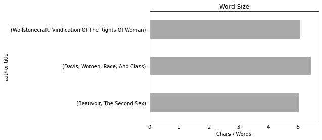

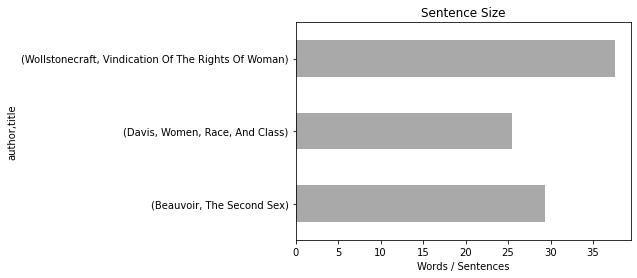

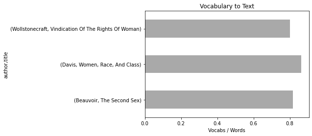

## Sentiment Analysis

Here is the summary table for sentiment and emotion score for the feminism school. As these scores are not relative to each other, they need to be normalized. The way it was normazlied was to divide each score by the total number of sentences.

| author | title | fear | trust | negative | positive | joy | disgust | anticipation | sadness | surprise | all_pos | all_neg | overview_net |
| --- | --- | --- | --- | --- | --- | --- | --- | --- | --- | --- | --- | --- | --- |
| Beauvoir | The Second Sex | 5439 | 9053 | 10663 | 15789 | 7590 | 3503 | 7239 | 4977 | 3292 | 39671 | 24582 | 15089 |
| Davis | Women, Race, And Class | 1852 | 2414 | 3376 | 4079 | 1658 | 836 | 1872 | 2099 | 631 | 10023 | 8163 | 1860 |
| Wollstonecraft | Vindication Of The Rights Of Woman | 1174 | 2936 | 2536 | 5372 | 1949 | 803 | 1799 | 980 | 772 | 12056 | 5493 | 6563 |

As an example, initially the sadness score was 4977, 2099, and 980, but can be normalized to 0.38, 0.68, and 0.38 respectively.

```
author          title
Beauvoir        The Second Sex                        0.382346
Davis           Women, Race, And Class                0.686172
Wollstonecraft  Vindication Of The Rights Of Woman    0.382962
dtype: float64
```

Now you see the emotions graph.

1. Wollstonecraft's article tends to have a lot more emotions than the others
2. All three have similar emotional patterns, however, Davis' article has a relatively higher "sadness" and "fear" score.
3. Although there seem to be a lot of positive emotions in the graph, because the algorithm of this sentiment analysis does not take into account context like"not kind", we cannnot fully trust the positivity.

As evidence, the most sad sentence by Davis follows:

Davis:Women, Race, And Class

> During this time,' Douglass pointed out, the justification for the murder of Negroes was said to be Negro conspiracies, Negro insurrections, Negro schemes to murder all the white people, Negro plots to burn the town and to commit violence generally but never a word was said or whispered about Negro outrages upon white women and children.

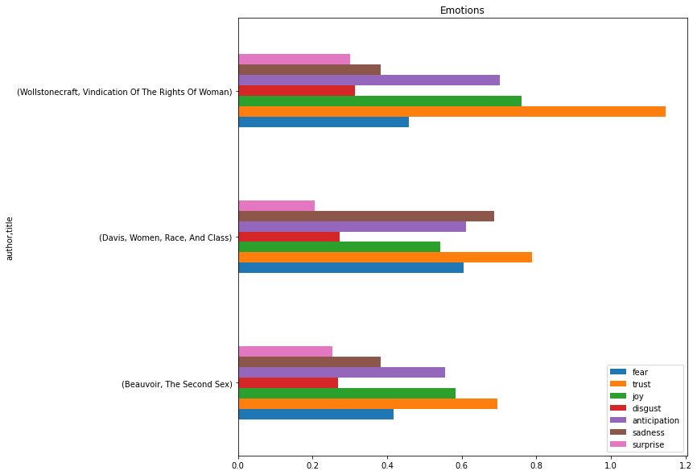

This sentiment score clearly shows that Wollstonecraft has a lot of positivity with less negativity. The sentence that had the highest positive score is as follows:

Wollstonecraft, Vindication Of the Rights Of Woman

> But when forbearance confounds right and wrong, it ceases to be a virtue; and, however convenient it may be found in a companion, that companion will ever be considered as an inferior, and only inspire a vapid tenderness, which easily degenerates into contempt Still, if advice could really make a being gentle, whose natural disposition admitted not of such a fine polish, something toward the advancement of order would be attained; but if, as might quickly be demonstrated, only affectation be produced by this indiscriminate counsel, which throws a stumbling block in the way of gradual improvement, and true melioration of temper, the sex is not much benefited by sacrificing solid virtues to the attainment of superficial graces, though for a few years they may procure the individual's regal sway.

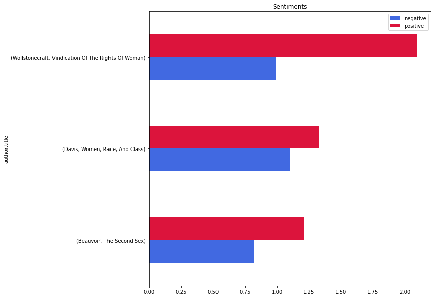

## Most Frequently Used Words

This Word Cloud technique picks the most frequently used words by each feminism philosopher. Because "woman" is obviously frequently used, I removed the word from the output. Therefore, all the frequently used words on the graph could suggest the relevancy to "woman". The relationship between the word "woman" and the other frequently used words will be further analyzed in the next section.

From each article's title and the output of this methodology, we can easily guess what the articles are about.  
"The Second Sex" by Beauvoir uses the words "mother", "marriage", "children", "desire", and "sexual". Apart from women being mother figures, this result might infer objectification of women.  
"Women, Race, And Class" by Davis uses the words "black", "white", "slave", "right", "suffrage", and "racism". In addition to discussing slavery, the text seems to emphasize black women's rights.  
"Vindication Of The Rights Of Woman" by Wollstonecraft uses the words "virtue", "reason", "mind", "affection", "respect", and "children". Although these are somewhat positive words, you can also see nagative words "never" and "without". These negative words usually change from a positive sentence to a negative sentence.Therefore, this text seems to address sort of hopefulness about women's position.

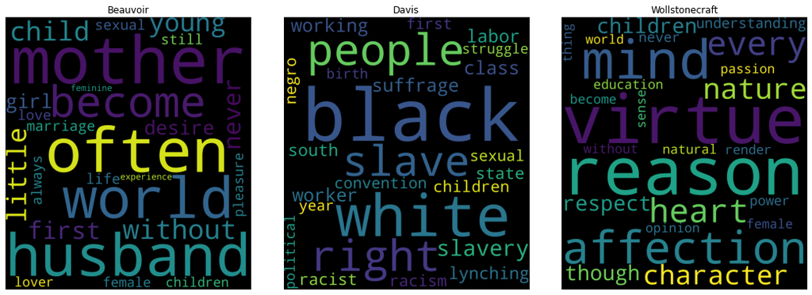

## Dynamics of Relationship

In the previous analysis, it was easy to get the sense of what the articles' claims are. However, using this dispersion plot, the context behind those words will become more clear because this dispersion plot shows when those words are mentioned. If some words were mentioned very closely, then it could be interpreted that they are related.

For **Beauvoir**, you can see the when "desire" gets mentioned, "sexual" and "woman" are frequently mentioned compared with "marriage" and "children". This supports the author claims that woman's sexual desire is neither positive nor negative. However, because Beauvoir's article had more positivity, there may be encouragement for women to have more sexual desire.

For **Davis**, when "suffrage" gets mentioned, "woman", "racism", "black", "white", "right" are frequently mentioned. Therefore, the author may emphasize the right of black woman for their suffrage.

For **Wollstonecraft**, the dipersion plot shows the equally scattered plots of words. You can observe that "children" gets mentioned when "affection" and "respect" are mentioned. However, negative words "never" and "without" are constantly mentioned simultaneously. This again suggests the opposite meaning of respect, virtue and so forth.

Now we know more about each claim by the philosophers by considering the context.

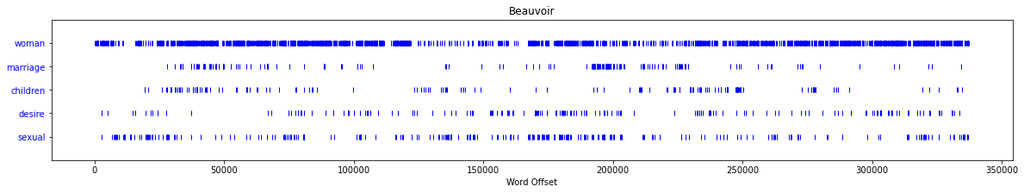

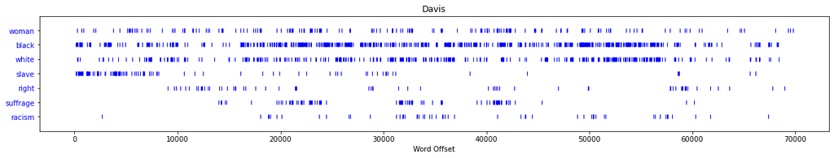

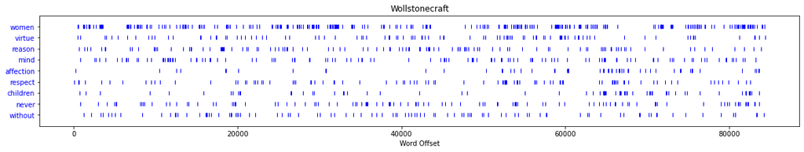

## Article Summarization

This text summarization techniques summarize what story each philosopher want to deliver to help our understanding of each article. As previously mentioned, this article summarization picked three most relevant sentences and combined them. The way the sentences were picked was to rank most frequently used words and find a sentence that has the most common words the best.

#### Most relevant three sentences

The Second Sex by Simone de Beauvoir:

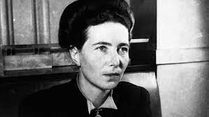

> I read between the lines; it seemed to me that he was answering me, giving me advice; I wrote him love letters; I wrote to him a lot In it suddenly came to me: it seemed to me that God was looking for a woman, that he was going to come and speak to me ; I had the impression he had given me a mission, chosen me to found a temple; I believed myself to be the center of a big complex where doctors would take care of women It was then that I was transferred to the Clermont mental institution There were young doctors who wanted to change the world: in my cabin, I felt their kisses on my fingers, I felt their sex organs in my hands; once, they told me: 'You are not sensitive, but sensual; turn over'; I turned over and I felt them in me: it was very pleasant The head doctor, Dr.…, was like a god; I really felt there was something when he came near my bed; he looked at me as if to say: one day, he looked at me insistently in a truly extraordinary way his green eyes became blue as the sky; they widened intensely in an incredible way he saw the effect that produced all the while speaking to another woman patient and he smiled and I thus remained fixated, fixated on Dr.… one nail does not replace another and in spite of all my lovers (I have had fifteen or sixteen), I could not separate myself from him; that's why he's guilty For more than twelve years, I have been having mental conversations with him when I wanted to forget him, he reappeared he was sometimes a bit mocking ' You see, I frighten you,' he said again, 'you can love others, but you will always come back to me …' I often wrote him letters, even making appointments I would keep.  
> For Montherlant, the woman lover is just as harmful as the mother; she prevents man from resurrecting the god in himself; woman's lot, he says, is life in its most immediate form, woman lives on feelings, she wallows in immanence; she has a mania for happiness: she wants to trap man in it; she does not experience the lan of her transcendence, she does not have the sense of grandeur; she loves her lover in his weakness and not in his strength, in his troubles and not in his joys; she would like him defenseless, so unhappy as to try to convince him of his misery regardless of any proof to the contrary.  
> The fact is that this sacrifice appears particularly heavy to men; few of them really wish in their hearts to see women accomplish themselves; those who scorn woman do not see what they would have to gain, and those who cherish her see too well what they have to lose; and it is true that presentday developments not only threaten feminine charm: in deciding to live for herself, woman will abdicate the functions as double and mediator that provide her with her privileged place within the masculine universe; for the man caught between the silence of nature and the demanding presence of other freedoms, a being who is both his peer and a passive thing appears as a great treasure; he may well perceive his companion in a mythical form, but the experiences of which she is the source or pretext are no less real: and there are hardly more precious, intimate, or urgent ones; it cannot be denied that feminine dependence, inferiority, and misfortune give women their unique character; assuredly, women's autonomy, even if it spares men a good number of problems, will also deny them many conveniences; assuredly, there are certain ways of living the sexual adventure that will be lost in the world of tomorrow: but this does not mean that love, happiness, poetry, and dreams will be banished from it.

#### Most relevant three sentences

Women, Race, And Class by Anggela Davis:

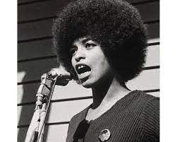

> A leader of the Boston Female Anti Slavery Society, Weston realized that the white mob sought to isolate and perhaps violently attack the Black women in attendance, and thus insisted that each white woman leave the building with a Black woman at her side.  
> While any Black person would realize that the story was contrived, the newspapers picked it up and widely disseminated the message that integrated women's clubs would result in the defilement of white womanhood.  
> By when the Philadelphia Female Anti Slavery Society was born in the wake of the founding convention of the American Anti Slavery Society, enough white women were manifesting their sympathetic attitudes toward the Black people's cause to have established the basis for a bond between the two oppressed groups.

#### Most relevant three sentences

Vindication Of The Rights Of Woman by Mary Wollstonecraft:

[figure not shown]

> Indeed the word masculine is only a bugbear: there is little reason to fear that women will acquire too much courage or fortitude; for their apparent inferiority with respect to bodily strength, must render them, in some degree, dependent on men in the various relations of life; but why should it be increased by prejudices that give a sex to virtue, and confound simple truths with sensual reveries? These two women may be much upon a par, with respect to reason and humanity; and changing situations, might have acted just the same selfish part; but had they been differently educated, the case would also have been very different. But for this epoch we must wait wait, perhaps, till kings and nobles, enlightened by reason, and, preferring the real dignity of man to childish state, throw off their gaudy hereditary trappings; and if then women do not resign the arbitrary power of beauty, they will prove that they have mind than man.

## Topic Modeling LDA

```
[   (   0,
        '0.001*"women" + 0.000*"black" + 0.000*"love" + 0.000*"men" + '
        '0.000*"like" + 0.000*"young" + 0.000*"life" + 0.000*"sexual"'),
    (   1,
        '0.001*"women" + 0.000*"like" + 0.000*"men" + 0.000*"love" + '
        '0.000*"young" + 0.000*"life" + 0.000*"mother" + 0.000*"human"'),
    (   2,
        '0.002*"women" + 0.002*"like" + 0.002*"love" + 0.002*"life" + '
        '0.002*"young" + 0.001*"girl" + 0.001*"little" + 0.001*"body"'),
    (   3,
        '0.009*"women" + 0.006*"like" + 0.005*"love" + 0.004*"life" + '
        '0.004*"men" + 0.004*"little" + 0.004*"young" + 0.003*"girl"'),
    (   4,
        '0.001*"women" + 0.001*"black" + 0.000*"white" + 0.000*"men" + '
        '0.000*"life" + 0.000*"like" + 0.000*"sexual" + 0.000*"little"'),
    (   5,
        '0.025*"women" + 0.022*"black" + 0.013*"white" + 0.006*"men" + '
        '0.005*"people" + 0.004*"new" + 0.004*"working" + 0.004*"slavery"'),
    (   6,
        '0.011*"women" + 0.007*"men" + 0.004*"mind" + 0.004*"reason" + '
        '0.004*"virtue" + 0.004*"respect" + 0.003*"human" + 0.003*"like"')]
```

[interactive chart not shown]

# *3. Comparison with Philosophers from Other Schools of Thought*

## Why Do We Need to Look at Other Schools of Thought?

So far, we focused on only the feminism school of thought to learn what are the values feminism authors are speaking regarding women.  
By looking at other philosophers, we can learn which topics lack mentions of women.  
In other words, if a philosopher mentions men a lot more often than women, the values or thoughts are something that woman might be not considered for.

This graph shows "both gender to text ratio of mentions by philosopher".  
Obviously, those philosophers who have low ratio for both genders tend to talk about something irrelevant to humans in general. A good example is Phenomenology with a low ratio for both genders.  
Therefore, let us pick up non-femnism school philosophers who have high ratio for male mentions - this time, 20% is our threshold.

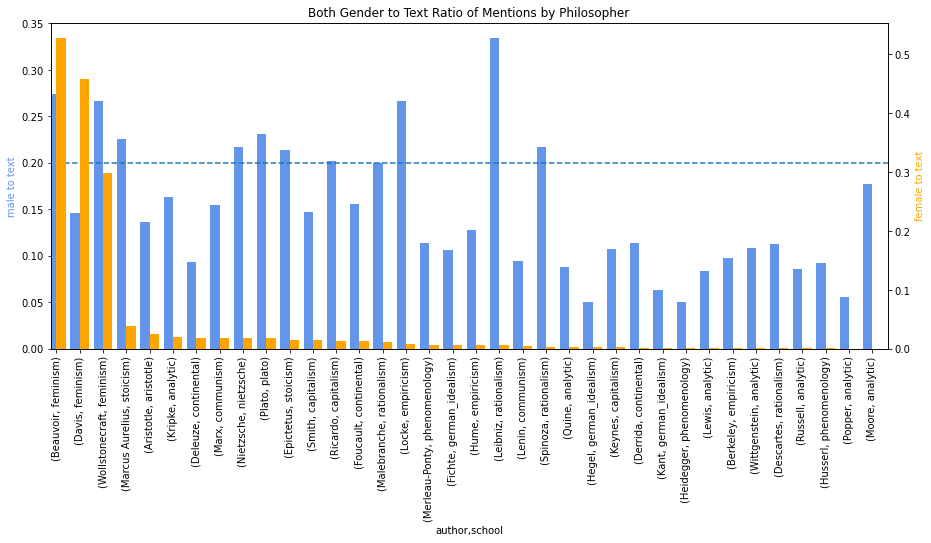

## Most Frequently Used Words

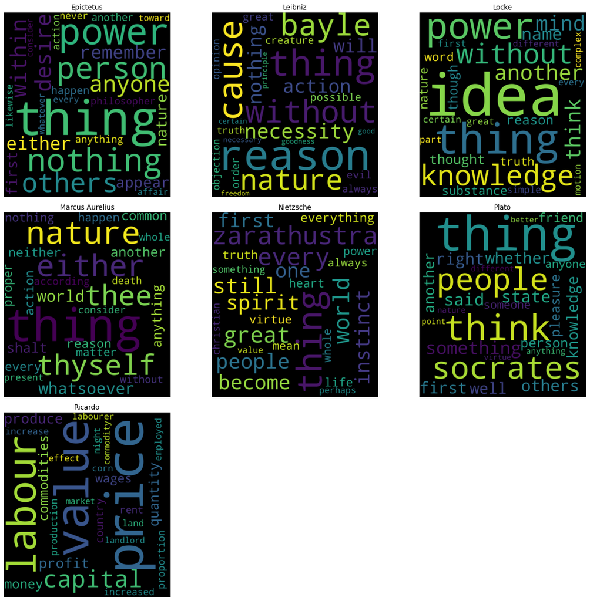

# *4. Summary*

#### In conclusion, as we can see the reuslt of this analysis, there are diverse topics to discuss within feminism. However, many philosphers of this dataset unfortunately chose to mention men over women irrespective of non-gender related topics. Therefore, in the future we hope to see future philosopher will include both men and women when disucssing variety of idea. Hopefully this will create more inclusive philosophical school of thgouhts.

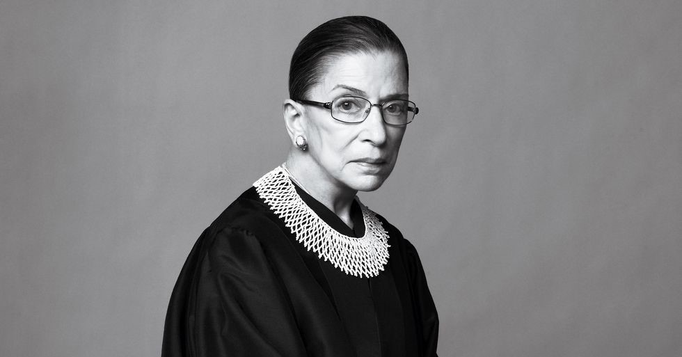

Please contact me if you have any question!